# Reproducible Research: Peer Assessment 1

Marek Schmidt

Sunday, December 14, 2014

## Loading and preprocessing the data

First load data from default directory path, file ‘activity.csv’ (downloaded & unzipped before):

```r
md <- read.csv("activity.csv")
observations <- nrow(md)
```

There are 17568 observations. Clean data by removing NAs (not measured steps during interval):

```r
mdrm <- md[!is.na(md$steps),]
observations_clean <- nrow(mdrm)
```

Now we have 15264 observations.

## What is mean total number of steps taken per day?

Preparing data into md_hist data.frame: sum of steps grouped by day:

```r
library(reshape2)
md_prep <- melt(mdrm, id="date", measure.vars="steps")
md_hist <- dcast(md_prep, date ~ variable, sum)
```

And print histogram from steps per day (NAs were removed, it is not a barplot):

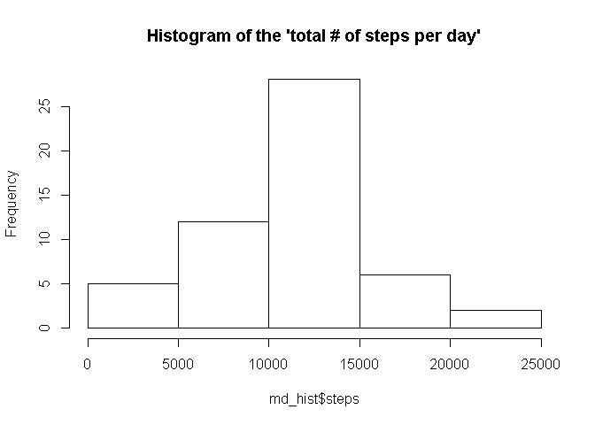

```r
hist(md_hist$steps, main="Histogram of the 'total # of steps per day'")
```

Now calculate mean & median for ‘Sum of steps per day’ (without NAs):

```r
mdrm_mean <- mean(md_hist$steps)
mdrm_median <- as.numeric(median(md_hist$steps))
```

## What is the average daily activity pattern?

Now we prepare time series plot of the 5-minute interval vs. average # of steps

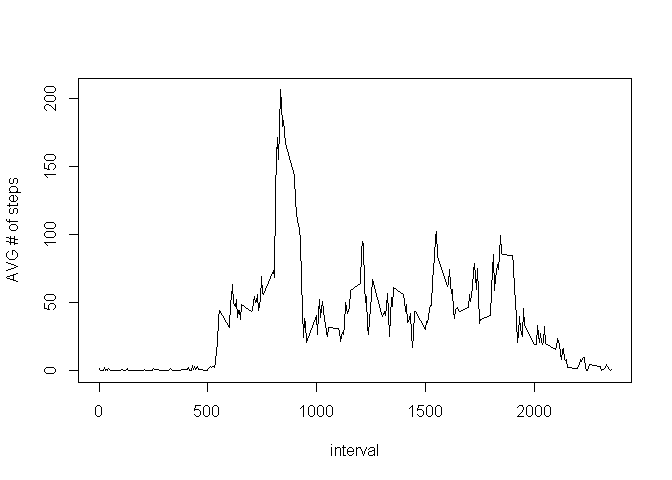

```r
md_prep2 <- melt(mdrm, id="interval", measure.vars="steps")
md_plot <- dcast(md_prep2, interval ~ variable, mean)
plot(md_plot, type="l", ylab="AVG # of steps")
```

Find maximum number of steps and associated interval:

```r
max_steps <- max(md_plot$steps)
max_interval <- md_plot[md_plot$steps==max_steps,"interval"]
```

Maximum average of steps was 206.1698113 and it was in interval: 835.

## Imputing missing values

1. Now calculate total missing values (NAs):

```r
missing <- sum(is.na(md$steps))
```

There is 2304 values where steps were not measured.

2. Our strategy for missing values will be to calculate average value from available data per interval and round it to integer, so we utilize md_plot and fill values rounded, eg. for particular interval it will be: missing_steps = round(md_plot$steps).
3. New dataset will be (we replace NAs with rounded averages from md_plot using inline function):

```r
md_fill <- md[is.na(md$steps),]
md_fill$steps <- as.integer(lapply(md_fill$interval, function(x) {round(md_plot[md_plot$interval == x,"steps"])} ) )
md_imputs <- rbind(mdrm, md_fill)
mdfc <- nrow(md_imputs)
```

Total count of new dataset called md_imputs is 17568. Now once again we print histogram from new dataset:

Preparing data into md_hist data.frame: sum of steps grouped by day:

```r
md_prep <- melt(md_imputs, id="date", measure.vars="steps")
md_hist2 <- dcast(md_prep, date ~ variable, sum)
```

And print histogram of the ‘total # of steps per day’, now difference is missing data averaged:

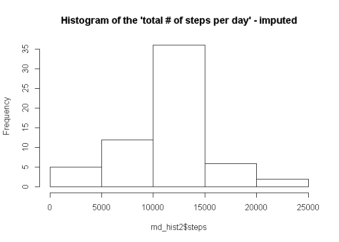

```r
hist(md_hist2$steps, main="Histogram of the 'total # of steps per day' - imputed")
```

Now calculate mean & median for ‘Sum of steps per day’ (without NAs):

```r
mdrm_mean2 <- mean(md_hist2$steps)
mdrm_median2 <- as.numeric(median(md_hist2$steps))
```

## Are there differences in activity patterns between weekdays and weekends?

```r
md_imputs$weekday <- weekdays(as.POSIXlt(md_imputs$date))
md_imputs$weekend <- as.integer(lapply(md_imputs$weekday, function(x) {if(x == "Saturday" || x == "Sunday") 1 else 0}))

md_prep_wend <- melt(md_imputs[md_imputs$weekend==1,], id="interval", measure.vars="steps")
md_prep_wday <- melt(md_imputs[md_imputs$weekend==0,], id="interval", measure.vars="steps")

md_plot2 <- dcast(md_prep_wend, interval ~ variable, mean)
md_plot3 <- dcast(md_prep_wday, interval ~ variable, mean)
```

Yes, there is different pattern during weekends as below (more walk during the day).

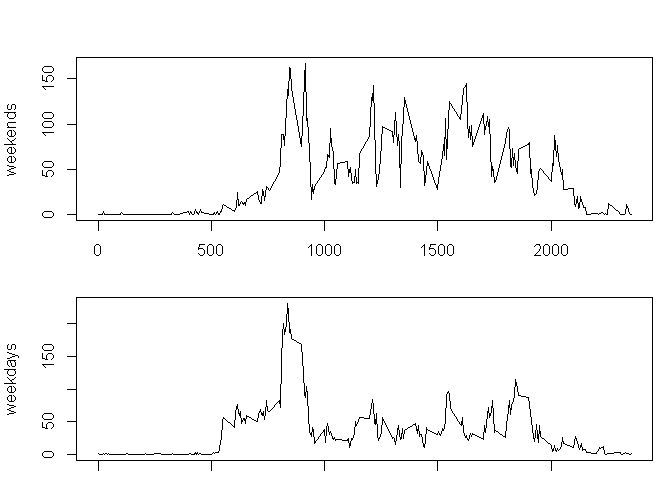

```r
par(mfrow=c(2,1), pin=c(5,2.8), mar=c(1,4,3,1))
plot(md_plot2, type="l", ylab="weekends")
plot(md_plot3, type="l", ylab="weekdays")
```